# Introduction to StatComp21040

## *Checkfunction2*

However,for some certain types,for example: **a sudden continuing increase/decrease like a cliff**, function Checkfunction1 fails to detect the most obvious change point as the change point’ slope might be smaller than the non-change ones’ slopes. Therefore, I further improve the original algorithm **using the ratio of two near slopes to magnify the change** which are computed with k nearest points.  
This function manifests priority in detecting possible change point in both **macro and micro perspective** (i.e. the span of period considered, by adjusting the parameter k, which means the number of k nearest points).  
The R codes for Checkfunction2 is as follows:

```r
Checkfunction2<-function (y,k,p){
  n<-length(y)
  deviation<-slope1<-slope2<-ratio<-numeric(n)
  for (i in 1:n){
    if (i>k & i<n-k ) {slope1[i]<-(y[i]-y[i-k])/k
    slope2[i]<-(y[i+k]-y[i])/k
    ratio[i]<-(slope1[i]/slope2[i])
    }
  }
  for (i in 1:n){
    if (ratio[i]<0&abs(slope1[i])>median(abs(slope1))&abs(slope2[i])>median(abs(slope2)) )
    {deviation[i]<-max(ratio[i],1/ratio[i])+max(abs(slope1[i]/median(slope1[i])),abs(slope2[i]/median(slope2[i])))       }
    else if (ratio[i]>0) {deviation[i]<-max(ratio[i],1/ratio[i]) }
    else {deviation[i]<--0.001 }
  }
  return (match(sort(deviation,decreasing=TRUE),deviation)[1:p])
}
```

## *Numeric* *Experiments*

**·Piece-wise constant case with a sudden change**

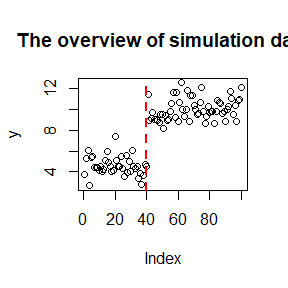

```r
set.seed(1234)
x1<-rnorm(40,5,1)
x2<-rnorm(60,10,1)
y<-c(x1,x2)
plot(y,main="The overview of simulation data")
abline(v=length(x1),col="red",lwd=2,lty=2)
```

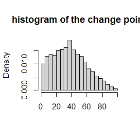

```r
s<-ChangePoint(y,v1=5,v2=10,e1=1,e2=1,N=10000,burnin=1000)
hist(s,freq=FALSE,main="histogram of the change point",xlab="")
```

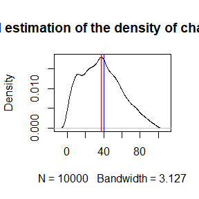

```r
dens<-density(s,bw = "nrd0",kernel='gaussian',window=kernel)
plot(dens,main="kernel estimation of the density of change point")
abline(v=dens$x[which.max(dens$y)],col="red")
abline(v=length(x1),col="blue")
```

```r
results<-matrix(0,nrow=1,ncol=2)
rownames(results)<-"Change point"
colnames(results)<-c("Theoretical","Computed")
results[,1]<-40
results[,2]<-dens$x[which.max(dens$y)]

library(knitr)
knitr::kable(results,align=rep('c', 5))
```

|  | Theoretical | Computed |
| --- | --- | --- |
| Change point | 40 | 37.56592 |

We can see that the theoretical change point detected by ChangePoint almost has the highest density value.

```r
Checkfunction1(y,3,2)
```

```
## [1] 41 40
```

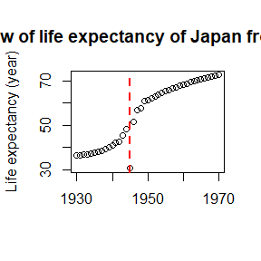

```r
Japan<-c(36.42584 ,36.59264 ,36.79944 ,37.03648 ,37.32840 ,37.67568 ,38.09784 ,38.60000 ,39.22192 ,39.97360 ,40.89944 ,42.04432 ,42.61632 ,45.65936 ,48.24248 ,30.53680 ,51.69000 ,56.83000 ,57.71000 ,61.15200 ,61.58300 ,62.42700 ,63.23400 ,64.00500 ,64.73900 ,65.43700 ,66.09900 ,66.72700 ,67.32200 ,67.88700 ,68.42400 ,68.93500 ,69.42600 ,69.89800 ,70.35100 ,70.78600 ,71.20000 ,71.59600 ,71.98000 ,72.35800 ,72.74000)
plot(x=1930:1970,y=Japan,main="The overview of life expectancy of Japan from 1930 to 1970",xlab="",ylab="Life expectancy (year)")
abline(v=which.min(Japan)+1930-1,col="red",lwd=2,lty=2)
```

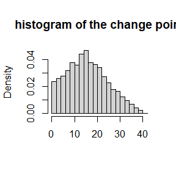

```r
s<-ChangePoint(Japan,v1=40,v2=65,e1=2,e2=2,N=10000,burnin=1000)
hist(s,freq=FALSE,main="histogram of the change point",xlab="")
```

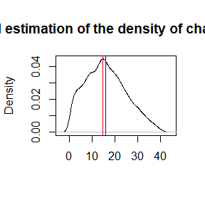

```r
dens<-density(s,bw = "nrd0",kernel='gaussian',window=kernel)
plot(dens,xlab="",main="kernel estimation of the density of change point")
abline(v=dens$x[which.max(dens$y)],col="red")
abline(v=which.min(Japan),col="blue")
```

```r
results<-matrix(0,nrow=1,ncol=2)
rownames(results)<-"Change point"
colnames(results)<-c("Theoretical","Computed")
results[,1]<-which.min(Japan)-1+1930
results[,2]<-round(dens$x[which.max(dens$y)]-1+1930)

library(knitr)
knitr::kable(results,align=rep('c', 5))
```

|  | Theoretical | Computed |
| --- | --- | --- |
| Change point | 1945 | 1944 |

ChangePoint performs well in this case.  
The change point of life expectancy of Japan occurs at **1945**,which corresponds to **Japan’s surrender in the world war Ⅱ**.

```r
Checkfunction1(Japan,2,1)+1930-1
```

```
## [1] 1945
```

The change point is detected precisely by Checkfunction1.  
**cliff type change point case**

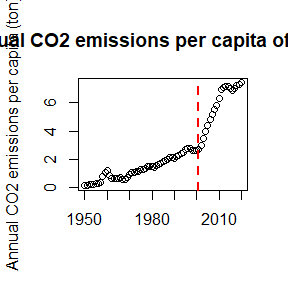

```r
China<-c(0.1422 ,0.1792 ,0.2197 ,0.2255 ,0.2668 ,0.3112 ,0.3473 ,0.4056 ,0.8193 ,1.1076 ,1.2096 ,0.8505 ,0.6738 ,0.6579 ,0.6504 ,0.6908 ,0.7401 ,0.6035 ,0.6320 ,0.7540 ,0.9763 ,1.0712 ,1.1140 ,1.1336 ,1.1317 ,1.2774 ,1.3010 ,1.3998 ,1.5355 ,1.5471 ,1.4944 ,1.4561 ,1.5629 ,1.6253 ,1.7434 ,1.8577 ,1.9216 ,2.0229 ,2.1322 ,2.1269 ,2.1114 ,2.1847 ,2.2630 ,2.3971 ,2.5203 ,2.7060 ,2.7989 ,2.7814 ,2.6419 ,2.6144 ,2.6649 ,2.7056 ,2.9622 ,3.4555 ,3.9482 ,4.4159 ,4.8481 ,5.1847 ,5.5386 ,5.7939 ,6.2950 ,6.9223 ,7.0623 ,7.1506 ,7.1353 ,7.0003 ,6.8742 ,6.9812 ,7.2077 ,7.3163 ,7.4117)
plot(x=1950:2020,y=China,main="The overview of Annual CO2 emissions per capita of China from 1950 to 2020",xlab="",ylab="Annual CO2 emissions per capita (ton)")
abline(v=2001,col="red",lwd=2,lty=2)
```

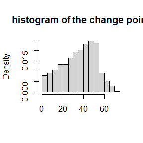

```r
#Changepoint method
s<-ChangePoint(China,v1=1,v2=5,e1=1,e2=2,N=10000,burnin=1000)
hist(s,freq=FALSE,main="histogram of the change point",xlab="")
```

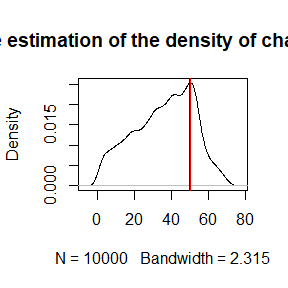

```r
dens<-density(s,bw = "nrd0",kernel='gaussian',window=kernel)
plot(dens,main="kerne estimation of the density of changepoint")
abline(v=dens$x[which.max(dens$y)],col="red")
abline(v=50,col="blue")
```

```r
results<-matrix(0,nrow=1,ncol=2)
rownames(results)<-"Change point"
colnames(results)<-c("Theoretical","Computed")
results[,1]<-2001
results[,2]<-round(dens$x[which.max(dens$y)]+1950)

library(knitr)
knitr::kable(results,align=rep('c', 5))
```

|  | Theoretical | Computed |
| --- | --- | --- |
| Change point | 2001 | 2000 |

```r
#Checkfunction2 method
micro<-Checkfunction2(China,3,6)+1950-1
macro<-Checkfunction2(China,10,6)+1950-1
results<-matrix(0,nrow=2,ncol=6)
rownames(results)<-c("micro perspective","macro perspective")
results[1,]<-micro
results[2,]<-macro

library(knitr)
knitr::kable(results,align=rep('c', 5))
```

| micro perspective | 1969 | 2001 | 1982 | 1958 | 1979 | 1971 |
| --- | --- | --- | --- | --- | --- | --- |
| macro perspective | 2001 | 2000 | 1999 | 2002 | 1998 | 1967 |

We can see Checkfunction2 returns not exactly the same possible change points with different settings of parameters.  
In a microscopic perspective,i.e. consider a short period, using small k, the detection turns delicate,corresponds to many historical events affecting China’s development of industry,and further affecting the CO2 emissions.  
But in a macroscopic perspective,i.e. consider a long span, using large k, the detection still turns useful. The years around **2001** are prominent, which corresponds to **China’s participation in WTO**, and of course this is the most important affair affecting China’s development in industry.

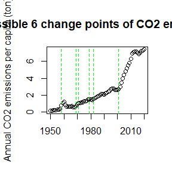

```r
plot(x=1950:2020,y=China,main="The most possible 6 change points of CO2 emissions of China",xlab="",ylab="Annual CO2 emissions per capita (ton)")
abline(v=micro,col="green",lwd=1.5,lty=2)
```

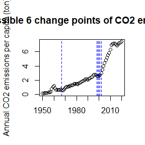

```r
plot(x=1950:2020,y=China,main="The most possible 6 change points of CO2 emissions of China",xlab="",ylab="Annual CO2 emissions per capita (ton)")
abline(v=macro,col="blue",lwd=1.5,lty=2)
```

In summary, all three methods work well in the numeric experiments. But pros and cons exist for different methods.  
ChangePoint is a general recommendation in detecting the most prominent change point. But as the model considered in the Changepoint is quite simple, it may not perform well in dealing with complex problems.  
Checkfunction1 and Checkfunction2 then can be used as assistance,which satisfies the detection of change points with different types. What’s more, they can also be used to help decide the span to use a one-time Changepoint for some times, which well surely improve the preciseness.